# R Notebook

# Metodo 2

Armamos una funcion para correr el modelo nulo. Solo hay que pasarle cuantos sujetos hay en total y cual es la tasa de acierto en la estimacion.

```r
modelo_nulo_fn <- function(cant_sujetos, tasa_acierto){
  aciertos_nulos <- rbinom(cant_sujetos, 1, tasa_acierto)
  ifelse(
    aciertos_nulos == 1,
    'ok',
    sample(c('sub','sobre'), cant_sujetos-sum(aciertos_nulos), replace = T)
  ) %>% as_tibble() %>% count(value) %>% pull(n)
}
```

```r
ggplot(
  data = h2_dataset,
  aes(x = autopercepcion)
) +
  geom_histogram() +
  facet_wrap(~error_selfperception)
```

```r
h2_dataset %>% filter(error_selfperception == FALSE) %>% transmute(x = autopercepcion/60) %>% summary(.x)
```

Graficamos la distribucion del modelo nulo

[figure not shown]

```r
h2_dataset_acorde <- h2_dataset %>% filter(error_selfperception == FALSE)
sample_mean <- function(data, indices){
  boot_data <- data[indices,]
  return(mean(boot_data$autopercepcion/60))
}
boot_media_acorde <- boot(
  h2_dataset_acorde,
  sample_mean,
  10000,
  parallel = 'multicore',
  ncpus = 5
)
plot(boot_media_acorde)
boot.ci(boot_media_acorde)
```

Corremos el modelo para los sujetos consistentes.

```r
comparacion_nula_consistente <- replicate(
  10000,
  modelo_nulo_fn(sum(true_freq_consistente$n), true_freq_consistente$n[1]/sum(true_freq_consistente$n))
)
rownames(comparacion_nula_consistente) <- c('ok', 'sobre', 'sub')
comparacion_nula_consistente <- comparacion_nula_consistente %>% t() %>% as_tibble()
```

Graficamos la distribucion del modelo nulo

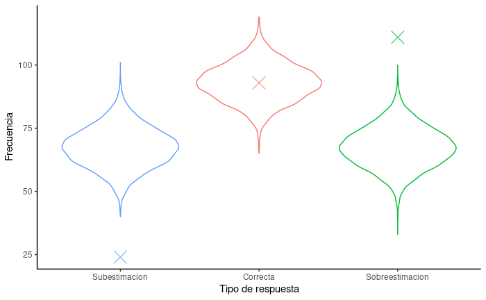

```r
plot_comparacion_consistente <- ggplot(
  comparacion_nula_consistente %>% pivot_longer(cols = everything())
) +
  geom_violin(aes(x = name, y = value, color = name)) +
  geom_point(data = true_freq_consistente,
               aes(x = sesgo, y = n, color = sesgo), shape = 4, size = 6) +
  theme_classic() + theme(legend.position = 'none') +
  ylab('Frecuencia') +
  scale_x_discrete(
    'Tipo de respuesta',
    labels=c("ok" = "Correcta", "sobre" = "Sobreestimacion",
                              "sub" = "Subestimacion"),
    limits = c('sub', 'ok', 'sobre')
  )
plot_comparacion_consistente
```

```r
diferencia_media_df <- data.frame(
  media_global = mean(h2_dataset$autopercepcion),
  media_modificada = sapply(
  seq(1, nrow(h2_dataset)),
  function(x) mean(h2_dataset$autopercepcion[-x])
  ),
  indice = seq(1, nrow(h2_dataset))
) %>%
  mutate(diferencia = media_global - media_modificada)

ggplot(
  data = diferencia_media_df,
    aes(x = indice, y = diferencia)
  ) +
  geom_point() +
  geom_hline(yintercept = 0)
```

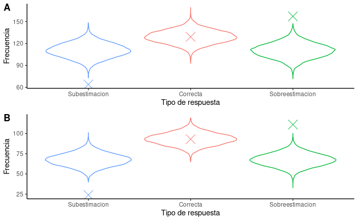

```r
ggarrange(plot_comparacion_todos, plot_comparacion_consistente, labels = LETTERS[1:2], ncol = 1)
ggsave('null_freq_relative.png', height = 7)
```

```r
hist(diferencia_media_df$diferencia)
```

# Metodo 3

Graficamos primero la distribucion de la variable de interes

[figure not shown]

```r
indices_acumulados <- diferencia_media_df %>%
  arrange(
    desc(
      abs(diferencia)
         )
    ) %>%
  pull(indice)

plot(
  x = seq(1:50),
  y = sapply(
  seq(1:50),
  function(x) mean(
    h2_dataset$autopercepcion[-c(indices_acumulados[1:x])]
    )
  ),
  type = 'l'
)
```

Chequeamos la normalidad de la distribucion.

[figure not shown]

```r
plot(
  x = seq(max(h2_dataset$autopercepcion), min(h2_dataset$autopercepcion), length.out = 1000),
  y = sapply(
  seq(max(h2_dataset$autopercepcion), min(h2_dataset$autopercepcion), length.out = 1000),
  function(x) mean(h2_dataset %>% filter(autopercepcion < x) %>% pull(autopercepcion))
  ),
  type = 'l'
)
```

Unimos a los dos graficos en uno solo

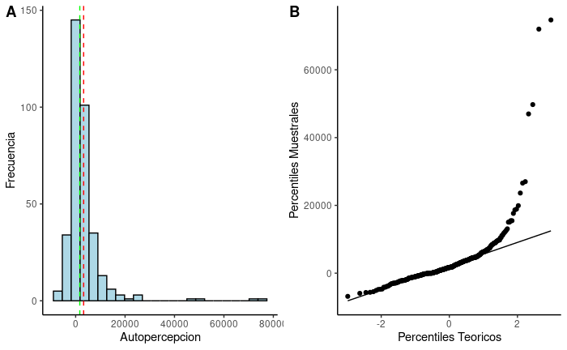

```r
ggarrange(
  ggplot(
  data = h3_dataset,
  aes(x = autopercepcion)
) +
  geom_histogram(color = 'black', fill = 'lightblue', binwidth = 3600) +
  geom_vline(aes(xintercept = mean(autopercepcion)), color = 'red', linetype = 'dashed') +
  geom_vline(aes(xintercept = median(autopercepcion)), color = 'green', linetype = 'dashed') +
  ylab("Frecuencia") + xlab("Autopercepcion") + theme_classic(),
  ggplot(h3_dataset, aes(sample = autopercepcion)) +
  stat_qq() + stat_qq_line() +
  xlab("Percentiles Teoricos") + ylab("Percentiles Muestrales") + theme_classic(),
  labels = LETTERS[1:2]
)
ggsave('autopercepcion_dist_all.png')
```

```r
sapply(
  seq(1,10),
  function(x) dplR::tbrm(h2_dataset$autopercepcion, C = x)
)
WRS2::winmean(h2_dataset$autopercepcion, tr = 0.2)
```

```r
plot(
  x = seq(max(h2_dataset$autopercepcion), min(h2_dataset$autopercepcion), length.out = 1000),
  y = sapply(
  seq(max(h2_dataset$autopercepcion), min(h2_dataset$autopercepcion), length.out = 1000),
  function(x) sum(h2_dataset$autopercepcion > x)
       ),
  type = 'l'
)
```

Hay varios outliers por lo que primero los detectamos para eliminarlos.

```r
autopercepcion_outliers <- performance::check_outliers(h3_dataset$autopercepcion, method = c('zscore_robust','iqr'))
h3_dataset_SinOutliers <- h3_dataset[autopercepcion_outliers == F,]
```

Repetimos los mismos graficos pero esta vez con el nuevo dataframe.

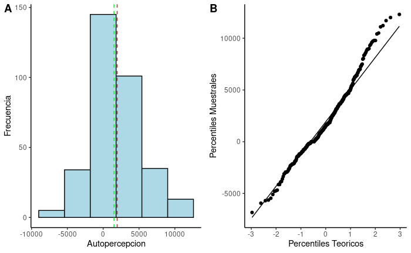

```r
ggarrange(
ggplot(
  data = h3_dataset_SinOutliers,
  aes(x = autopercepcion)
) +
  geom_histogram(color = 'black', fill = 'lightblue', binwidth = 3600) +
  geom_vline(aes(xintercept = mean(autopercepcion)), color = 'red', linetype = 'dashed') +
  geom_vline(aes(xintercept = median(autopercepcion)), color = 'green', linetype = 'dashed') +
  ylab("Frecuencia") + xlab("Autopercepcion") + theme_classic(),
ggplot(h3_dataset_SinOutliers, aes(sample = autopercepcion)) +
  stat_qq() + stat_qq_line() +
  xlab("Percentiles Teoricos") + ylab("Percentiles Muestrales") + theme_classic(),
labels = LETTERS[1:2]
)
ggsave('autopercepcion_dist_SinOutliers.png')
```

```r
ggplot(
  data = h2_dataset,
  aes(x = autopercepcion)
) +
  geom_histogram() +
  facet_wrap(~error_selfperception)
```

```r
t.test(h3_dataset_SinOutliers$autopercepcion)
```

```
    One Sample t-test

data:  h3_dataset_SinOutliers$autopercepcion
t = 10.265, df = 332, p-value < 2.2e-16
alternative hypothesis: true mean is not equal to 0
95 percent confidence interval:
 1575.089 2321.872
sample estimates:
mean of x
  1948.48
```

```r
effectsize::cohens_d(h3_dataset_SinOutliers$autopercepcion, mu = 0)
```

```
Cohen's d |       95% CI
------------------------
0.56      | [0.45, 0.68]
```

```r
t.test(h3_dataset_SinOutliers %>% filter(error_selfperception == F) %>% pull(autopercepcion))
```

```
    One Sample t-test

data:  h3_dataset_SinOutliers %>% filter(error_selfperception == F) %>% pull(autopercepcion)
t = 9.2217, df = 248, p-value < 2.2e-16
alternative hypothesis: true mean is not equal to 0
95 percent confidence interval:
 1638.151 2527.945
sample estimates:
mean of x
 2083.048
```

```r
effectsize::cohens_d(h3_dataset_SinOutliers %>% filter(error_selfperception == F) %>% pull(autopercepcion), mu = 0)
```

```
Cohen's d |       95% CI
------------------------
0.58      | [0.45, 0.72]
```

```r
t.test(h3_dataset_SinOutliers %>% filter(error_selfperception == F & error_otherperception == F) %>% pull(autopercepcion))
```

```
    One Sample t-test

data:  h3_dataset_SinOutliers %>% filter(error_selfperception == F & error_otherperception == F) %>% pull(autopercepcion)
t = 8.3611, df = 219, p-value = 7.224e-15
alternative hypothesis: true mean is not equal to 0
95 percent confidence interval:
 1519.045 2456.037
sample estimates:
mean of x
 1987.541
```

```r
effectsize::cohens_d(h3_dataset_SinOutliers %>% filter(error_selfperception == F & error_otherperception == F) %>% pull(autopercepcion), mu = 0)
```

```
Cohen's d |       95% CI
------------------------
0.56      | [0.42, 0.71]
```

```r
median(h2_dataset$autopercepcion)

plot(
  x = seq(0.01,0.25, length.out = 1000),
  y = sapply(
  seq(0.01,0.25, length.out = 1000),
  function(x) mean(h2_dataset$autopercepcion, trim = x)
       ),
  type = 'l'
)
```